# Projekt 732G33

### Uppgift 3

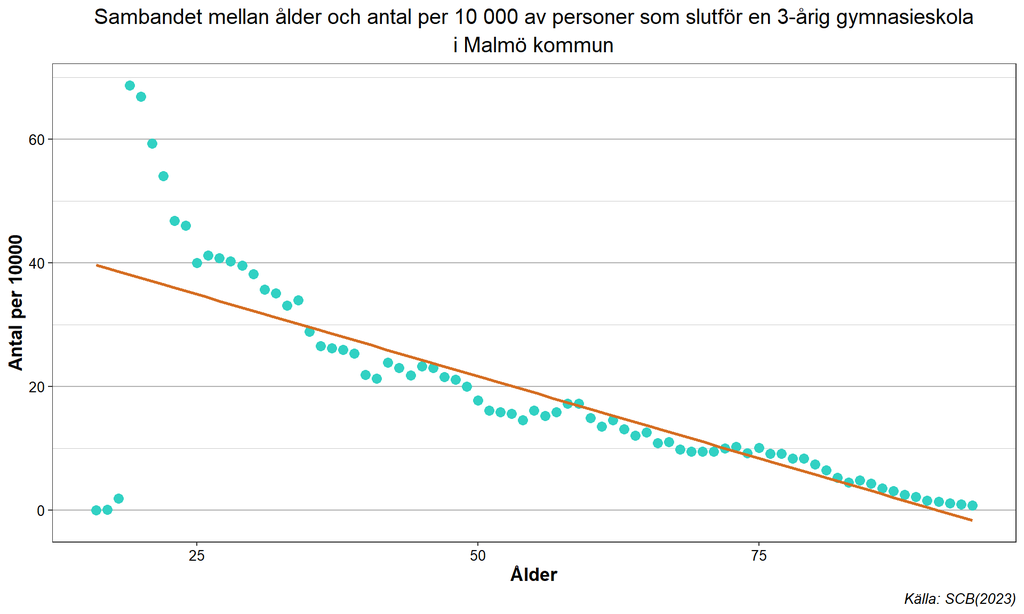

Figur 3: Spridningsdiagram visar sambandet mellan ålder och antal per 10 000 av personer som slutför 3 års gymnasieutbildning

Diagrammet ovan visar ett stark negativt samband mellan åldel och antal per 10000 med x-axel är ålder och y-axel är andelen. Regressionlinjer visar en nedåtgående trend från vänster till höger ge, man kan säga ju öka ålder, desto minska andel av personer som slutför 3-årig gymnasieskolan.

### Uppgift 4

```
##
##  Pearson's product-moment correlation
##
## data:  x and y
## t = -14.555, df = 156, p-value < 2.2e-16
## alternative hypothesis: true correlation is not equal to 0
## 95 percent confidence interval:
##  -0.8180984 -0.6837826
## sample estimates:
##        cor
## -0.7588984
```

### Uppgift 6 (a)

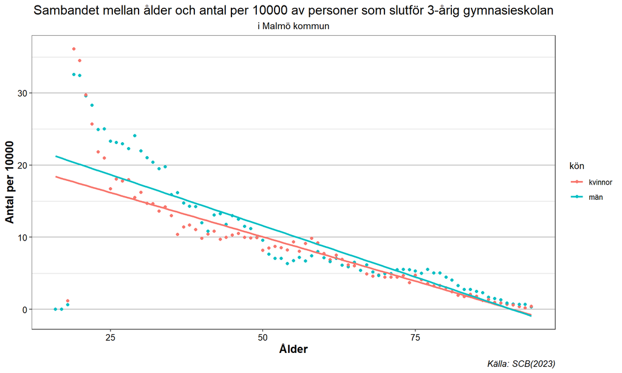

Figur 4: Spridningsdiagram visar sambandet mellan män och kvinnor per 10 000 invånare som slutför 3 års gymnasieutbildning

Ovanför visar ett spridningsdiagram likadant med tidigare diagrammet men det är upppdelad efter kön med gröna färg är män och röda färg är kvinnor. Skillnaden är inte stor eftersom både kön visar samma en nedåtgående trend från vänster till höger.

### Uppgift 6 (b)

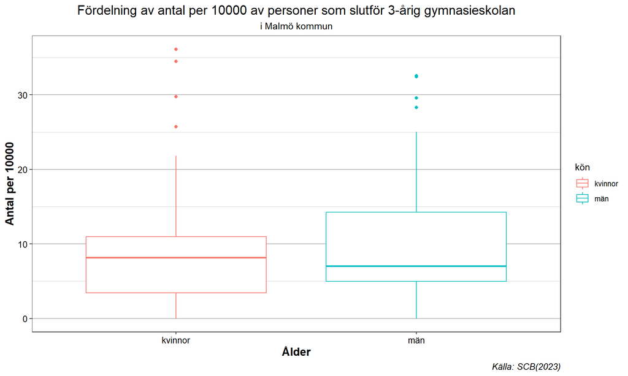

Figur 5: Lådagram visar fördelning av antal män och kvinnor per 10 000 invånare som slutför 3 års gymnasieutbildning

Diagrammet ovan visar ett lådagram med x-axel är ålder och y-axel antal per 10000 och det är också uppdelad efter könen. De flesta observationer av både män och kvinnor har ingen stor skillnad, de ligger mellan 0 till 22 för kvinnor och 25 för män.

### Uppgift 6 (c)

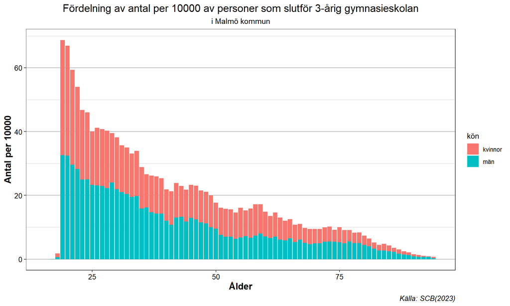

Figur 6: Grupperad stapeldiagram visar fördelning av antal män och kvinnor per 10 000 invånare som slutför 3 års gymnasieutbildning

Ovanför beskrivs en grupperad stapeldiagram av fördelning av antal personer som slutför 3-årig gymnasieskolan efter ålder på kommunalsnivå med x-axel är ålder och y-axel är antal. Samma med den första diagrammet har det skett ett karftig minskning från vänster till höger, dvs att det spela ingen roll med könen andel av personer som slutför 3-årig gymnasieskolan minska när ålder öka.

### Uppgift 6 (d)

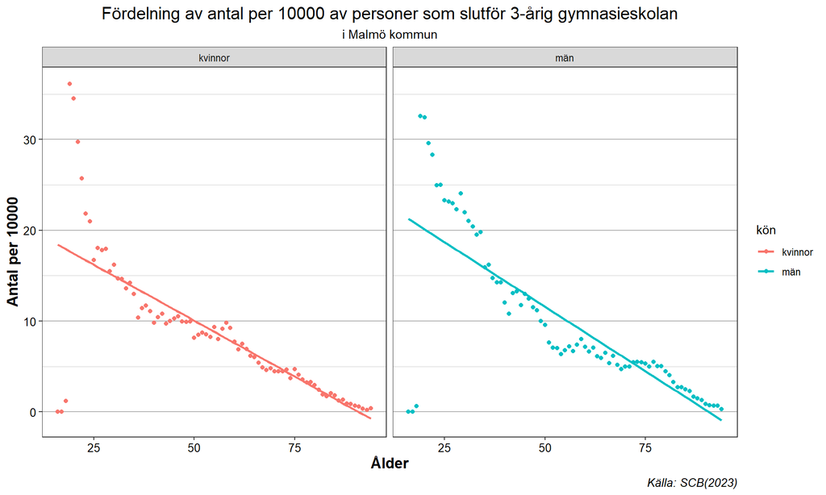

Figur 7: Spridningsdiagram uppdelad i två plottar, visar fördelning av antal män och kvinnor per 10 000 invånare som slutför 3 års gymnasieutbildning

Samman slutsats med diagrammet 6a men nu det uppdelad till två olika celler istället ligger på en. Både har samma en nedåtgående trend från vänster till höger och skillnaden mellan två könen är inte stor.

## Dataanalys av tidseriedata

### Uppgift 1

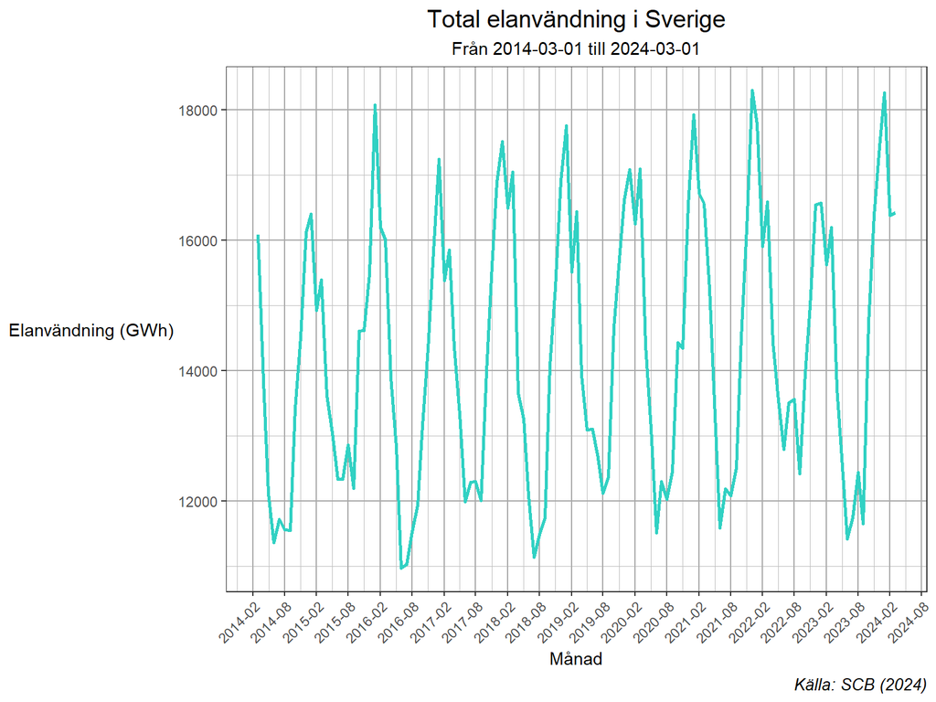

Figur 8: Linjediagram visar total elanvändning i Sverige från 2014-03-01 till 2024-03-01

### Uppgift 2

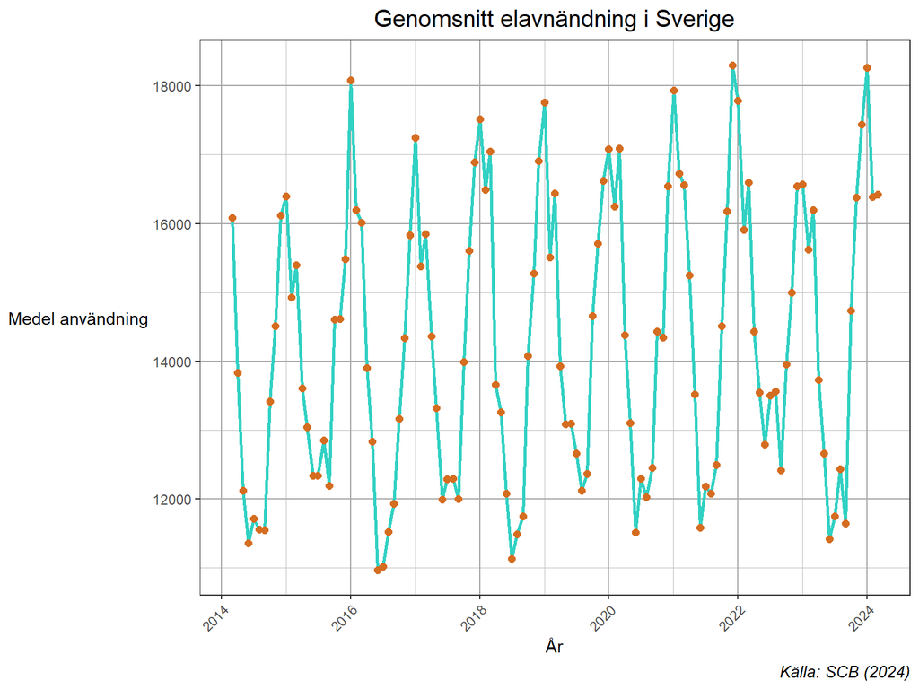

Figur 9: Linjediagram visar genomsnitt elanvändning i Sverige

Tabell 2: Genomsnittliga elanvändningen i Sverige från 2014-03-01 till 2024-03-01

| månad | mean_elanvandning_gwh |
| --- | --- |
| 2014-03-01 | 16087 |
| 2014-04-01 | 13832 |
| 2014-05-01 | 12123 |
| 2014-06-01 | 11359 |
| 2014-07-01 | 11713 |
| 2014-08-01 | 11557 |
| 2014-09-01 | 11552 |
| 2014-10-01 | 13419 |
| 2014-11-01 | 14512 |
| 2014-12-01 | 16120 |
| 2015-01-01 | 16400 |
| 2015-02-01 | 14925 |
| 2015-03-01 | 15397 |
| 2015-04-01 | 13612 |
| 2015-05-01 | 13046 |
| 2015-06-01 | 12337 |
| 2015-07-01 | 12339 |
| 2015-08-01 | 12854 |
| 2015-09-01 | 12196 |
| 2015-10-01 | 14609 |
| 2015-11-01 | 14615 |
| 2015-12-01 | 15485 |
| 2016-01-01 | 18076 |
| 2016-02-01 | 16196 |
| 2016-03-01 | 16013 |
| 2016-04-01 | 13900 |
| 2016-05-01 | 12832 |
| 2016-06-01 | 10973 |
| 2016-07-01 | 11025 |
| 2016-08-01 | 11526 |

[output cut: 91 more lines]